# Plague Phylodynamics and Phylogeography

*This manuscript ([permalink](https://rawcdn.githack.com/ktmeaton/obsidian-public/540f66f6/academic/Plague%20Phylodynamics%20and%20Phylogeography%20Paper.html)) was automatically generated from [ktmeaton/obsidian-public@540f66f6](https://github.com/ktmeaton/obsidian-public/tree/540f66f6) on May 25, 2021.*

## Authors

- **Katherine Eaton**  
  0000-0001-6862-7756 · ktmeaton  
  McMaster Ancient DNA Center; Department of Anthropology, McMaster University
- **Leo Featherstone**  
  0000-0002-8878-1758  
  The Peter Doherty Institute For Infection and Immunity , University of Melbourne
- **Sebastian Duchene**  
  0000-0002-2863-0907 · sebastianduchene  
  The Peter Doherty Institute For Infection and Immunity , University of Melbourne
- **Hendrik Poinar**  
  0000-0002-0314-4160  
  McMaster Ancient DNA Center; Department of Anthropology, McMaster University

## Keywords

- Plague
- Yersinia pestis
- Phylodynamics
- Phylogeography

## Introduction

Plague has an impressively long and expansive history as a human pathogen. The earliest evidence of the plague bacterium *Yersinia pestis* comes from ancient DNA studies, dating its emergence to at least the Neolithic [1,2]. Since then, *Y. pestis* has traveled extensively due to ever-expanding global trade networks and the ability to infect a diverse array of mammalian hosts [3,4]. Few regions of the ancient and modern world remain untouched by this disease, as plague has an established presence on every continent except Oceania [5].

Accompanying this prolific global presence is unnervingly high mortality. The infamous medieval Black Death is estimated to have killed more than half of Europe’s population [6]. This virulence can still be observed in the post-antibiotic era, where case fatality rates range from 22-71% [7]. As a result, plague maintains its status as a disease that is of vital importance to current public health initiatives.

This high priority disease status is unsurprising given that *Y. pestis* is a member of the Enterobacteriaceae family. This family includes enteric pathogens such as *Escherichia coli* and *Salmonella typhi* that are commonly transmitted by contaminated food and water. In comparison, the plague bacterium is unique among this family due to a striking difference in host habitat and transmission. *Y. pestis* commonly resides in the blood of its mammalian hosts and can be transmitted to new hosts through an infectious fleabite [8]. In addition to these tissues, the plague bacterium is also capable of colonizing parts of the mammalian immune system including the lymphatic and reticuloendothelial systems. The large diversity of media in which *Y. pestis* has adapted to colonize is particularly surprising given that it only recently (within the last 20,000 years) diverged as a clone of its parent species Yersinia pseudotuberculosis [9].

Despite a close genetic similarity between *Y. pestis* and *Y. pseudotuberculosis*, in which they share 97% gene identity, they differ widely in their transmission and pathogenecity [10]. Whereas *Y. pseudotuberculosis* causes gastrointestinal disease and is transmitted by the food-borne route, *Y. pestis* is primarily transmitted between mammalian hosts by fleas and causes septicemia, pneumonia, and lymphadenitis. Because of this apparent contradiction of genetic homogeneity and diverse phenotypes, an extensive body of research has formed to address how, when, and where, these epidemiological shifts occurred.

### Objectives

1. Curate and critique publicly available Y. pestis genomes. Discuss how sampling bias drives our current understanding of plague.
2. To propose a nuanced phylodynamics model.
3. To critique interpretations drawn from phylogeographic approaches?

## Materials and Methods

### Workflow Overview

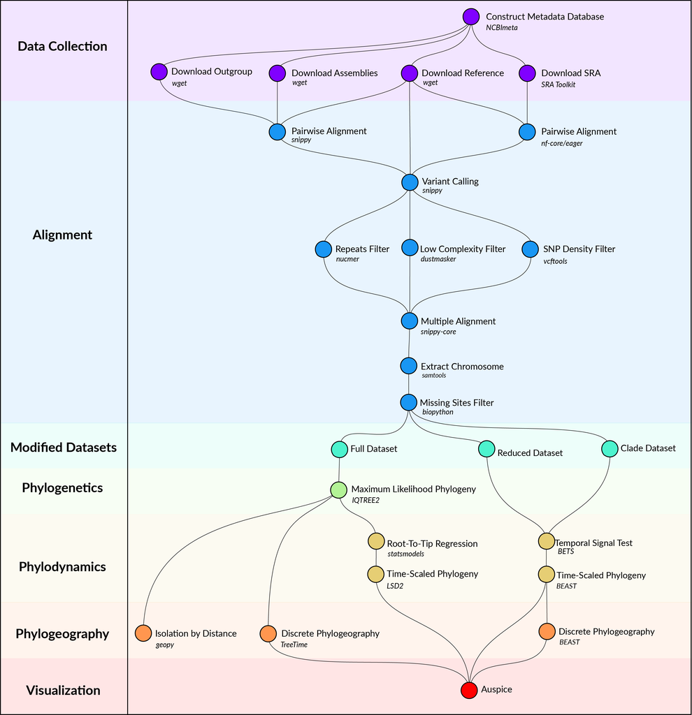

Figure 1: Computational methods workflow.

### Data Collection

*Y. pestis* genome sequencing projects were retrieved from the NCBI databases using NCBImeta [11]. 1657 projects were identified and comprised three genomic types:

- 586 modern assembled
- 184 ancient unassembled
- 887 modern unassembled

The 887 modern unassembled genomes were excluded from this project, as the wide variety of laboratory methods and sequencing strategies precluded a standardized workflow. In contrast, the 184 ancient unassembled genomes were retained given the relatively standardized, albeit specialized, laboratory procedures required to process ancient tissues. Future work will investigate computationally efficient methods for integrating more diverse datasets.

Collection location, collection date, and collection host metadata were curated by cross-referencing the original publications. Collection location was transformed to latitude and longitude coordinates using GeoPy and the Nominatim API for OpenStreetMap [12,13,14]. Coordinates were standardized at a sub-country resolution, taking the centroid of the parent province/state. Collection dates were standardized according to their year, and recording uncertainty arising from missing data and radiocarbon estimates. Collection host was the most diverse field with regards to precision, ranging from colloquial nomenclature (*“rat”*) to a genus species taxonomy (*“Meriones libycus”*). For the purposes of this study, collection host was recorded as *Human*, *Non-Human*, or *Not Available*, given the inability to differentiate non-human mammalian hosts.

Genomes were removed if no associated date or location information could be identified in the literature, or if there was documented evidence of laboratory manipulation.

Two additional datasets were required for downstream analyses. First, *Y. pestis* strain CO92 (GCA_000009065.1) was used as the reference genome for sequence alignment and annotation. Second, *Yersinia pseudotuberculosis* strains NCTC10275 (GCA_900637475.1) and IP32953 (GCA_000834295.1) served as an outgroup to root the maximum likelihood phylogeny.

### Alignment

Modern assembled genomes were aligned to the reference genome using Snippy, a pipeline for core genome alignments [15]. Modern genomes were removed if the number of sites covered at a minimum depth of 10X was less than 70% of the reference genome.

A multiple sequence alignment was constructed using the Snippy Core module of the Snippy pipeline. The output alignment was filtered to only include chromosomal variants and to exclude sites that had more than 5% missing data.

### Modified Datasets

To investigate the influence of between-clade variation in substitution rates, the multiple alignment was separated into the major clades of *Y. pestis*, which will be referred to as the *Clade* dataset. Clade and subclade labeling was derived from the five-branch population structure accompanied by a biovar abbreviation ([18]. Only one modification was made, in that the subclade associated with the Plague of Justinian (0.ANT4) was considered to be a distinct clade from its parent (0.ANT) due to its geographic, temporal, and ecological uniqueness. In total, 12 clades were considered and are described in Table 1.

To improve the performance and convergence of Bayesian analysis, a subsampled dataset was constructed and will be referred to as the *Reduced* dataset. Clades that contained multiple samples drawn from the same geographic location and the same time period were reduced to one representative sample. The sample with the shortest terminal branch length was prioritized, to diminish the influence of uniquely derived mutations on the estimated substitution rate. An interval of 25 years was identified as striking an optimal balance, resulting in 200 representative samples.

### Phylogenetics

Model selection was performed using Modelfinder which identified the K3Pu+F+I model as the optimal choice based on the Bayesian Information Criterion (BIC) [19]. A maximum-likelihood phylogeny was then estimated across 10 independent runs of IQTREE [20]. Branch support was evaluated using 1000 iterations of the ultrafast bootstrap approximation, with a threshold of 95% required for strong support [21].

### Phylodynamics

#### Time Tree

A maximum-likelihood timetree was estimated using a least-squares approach as implemented in LSD2 [22]. Rate variation was modeled using a lognormal relaxed clock with default parameters for the mean (1.0) and the standard deviation (0.2). The outgroup *Y. pseudotuberculosis* was used to root the tree and then subsequently removed.

> Note: I’m still pondering the best choice of parameters for the LSD2 relaxed clock.

### Phylogeography

Geographic location was modeled as a discrete state with transitions following a GTR mugration model as implemented in TreeTime [23].

## Results

### Phylogenetics

The nomenclature used to described the phylogeny of *Y. pestis* has become increasingly complex recent years. This complexity arises because plague is categorized based not just on a few traits, but on a vast assortment of historical, ecological, biochemical, and molecular characteristics.

Arguably the most important molecular event is the Big Bang Polytomy, from which arose four monophyletic clades: Branches 1-4 (Figure 2). All lineages that diverged prior to this multifurcation are grouped into Branch 0. The associated branch number of a *Y. pestis* strain thus serves as a prefix before a clade designation.

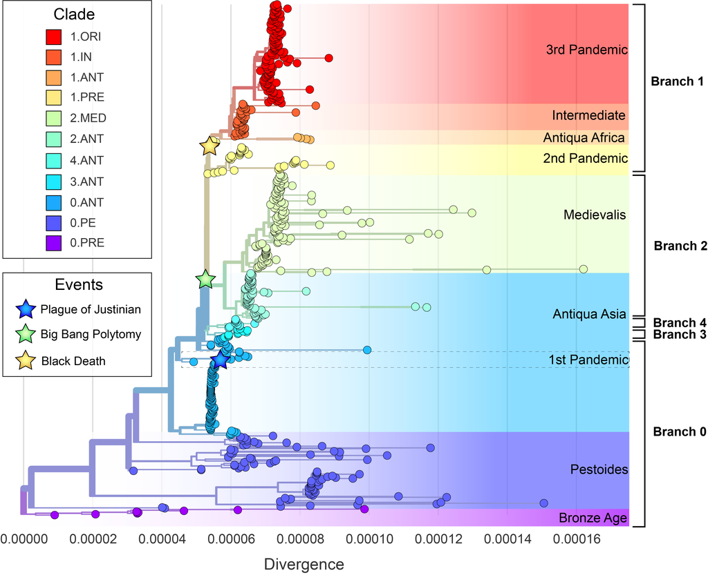

Figure 2: *Y. pestis* maximum-likelihood phylogeny.

#### Time

> How has the known diversity of plague changed over time?

In addition to the biovar nomenclature is the categorization of plague according to collection date. Historical strains of plague isolated prior to the 20th century cluster into three time periods: the Late Neolithic Bronze Age (LNBA), Roman Period/Late Antiquity(?), and the Medieval Period (3). For example, all strains of *Y. pestis* isolated in the Roman period group together in Branch 0 and form a distinct subclade within 0.ANT. Similarly, all Medieval strains of *Y. pestis* cluster together in Branch 1 as clade 1.PRE. The LNBA is a notable exception as mixing between clades 0.PE and 0.PRE is observed.

However, collection date and collection location are highly confounded as ancient DNA sampling strategies have predominantly targeted Western Europe. Due to this sampling bias, it is challenging to evaluate whether multiple strains of plague have co-occured in human populations in the past.

An additional observation is that the temporal sampling strategy of genomic data reflects greater interest in *Y. pestis* as a historical pathogen, rather than a public health threat to modern humans. One example of this is that the Medieval Plague in Western Europe (Clade 1.PRE) has more representative samples than all of the African continent (Clade 1.ANT). Sequencing initiatives are greatly needed that shift the balance away from Eurocentrism and encompass a greater diversity of affected populations.

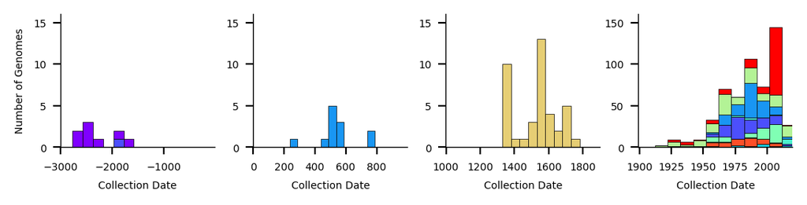

Figure 3: Temporal distribution of *Y. pestis* genomes.

#### Geography

The geographic distribution of *Y. pestis* reflects a complex dispersal history (Figure 4 .B). Many regions have been colonized by diverse strains of *Y. pestis*. This diversity can be contemporaneous, such as endemic foci in the Caucausus and Western China (Clade 0.PE). Alternatively, this diversity may occur over multiple centuries through distinct re-introductions and extinctions, as seen in the historical epidemics of Europe (Clades 0.ANT and 1.PRE). In these examples, a relatively large amount of genetic diversity appears in a small geographic range. In contrast, regions such as the Americas have been colonized by a single strain of *Y. pestis* (Clade 1.ORI) which shows a relatively small amount of genetic diversity over a tremendously large geographic range.

An important consideration is that the geographic sampling strategy of *Y. pestis* genomes (Figure 4 .A) does not reflect the known distribution of modern plague [24], let alone historical pandemics. Nor does it adequately characterize the most heavily affected regions of the world, namely Madagascar and the Democratic Republic of the Congo [5]. The over-sampling of East Asia has been previously described by 25 and considerably drives the hypothesis that *Y. pestis* originated in China [18,26]. This once established hypothesis is now in contention, as the most basal strains of *Y. pestis* (Clades 0.PRE and 0.PE) have been isolated from all across Eurasia.

> The geographic distribution of *Y. pestis* genomes reflects the *sampling history* more so than the *natural history* of the disease.

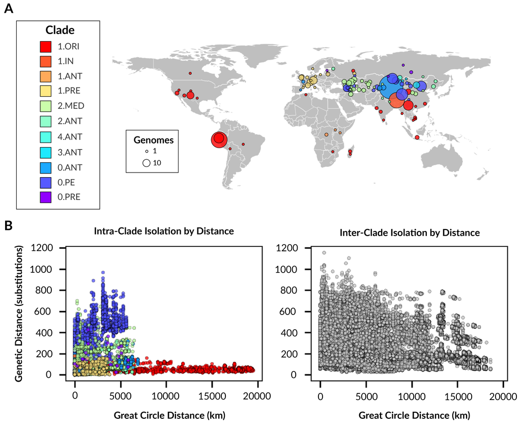

Figure 4: Spatiotemporal distribution of *Y. pestis* genomes. **A**: Geographic distribution, **B**: Isolation by distance as a function of geographic distance and genetic distance.

#### Hosts

> Plague can cause disease in humans at any time, and from anywhere. There are virtually no lineages that are “safe” for humans. Thus plague as a disease is treated with exceptional caution.

[figure not shown]

Figure 5: Distribution of human vs. non-human samples.

#### Pandemics

Finally, *Y. pestis* can be structured according to historically documented human pandemics. Ancient isolates of *Y. pestis* that date to the Late Antiquity are hypothesized to be associated with First Pandemic which includes the Plague of Justinian. Medieval isolates have been linked to the Second Pandemic and the Black Death based on spatiotemporal overlap.

> Are the Second and Third Pandemics genetically separate? If so, what does this mean for clade 1.ANT? Is it Pandemic 2.5? Why are there no pandemics attribute to branch 2? The two clades within branch 2 stretch across Asia, from the Caucasus to Eastern China to South Asia.

### Phylodynamics

#### Rate Variation

Table 1: Temporal signal statistics by clade based on a root-to-tip linear regression.

| Branch | Clade | Origin | RTT R<sup>2</sup> | RTT p-value | BETS Bayes Factor |
| --- | --- | --- | --- | --- | --- |
| All | All | Ancient, Modern | 0.09 | 3.81E-14* |  |
| 0 | 0.PRE | Ancient | 0.91 | 1.53E-04* |  |
| 0 | 0.PE | Modern | 0.01 | 2.25E-01 |  |
| 0 | 0.ANT4 | Ancient | 0.66 | 7.84E-04* |  |
| 0 | 0.ANT | Modern | -0.01 | 7.35E-01 |  |
| 1 | 1.ANT | Modern | 0.45 | 2.03E-01 |  |
| 1 | 1.IN | Modern | 0.0 | 3.24E-01 |  |
| 1 | 1.ORI | Modern | 0.04 | 1.32E-02* |  |
| 1 | 1.PRE | Ancient | 0.76 | 1.68E-13* |  |
| 2 | 2.ANT | Modern | 0.05 | 5.96E-02 |  |
| 2 | 2.MED | Modern | 0.01 | 1.86E-01 |  |
| 3 | 3.ANT | Modern | -0.04 | 4.39E-01 |  |
| 4 | 4.ANT | Modern | -0.11 | 8.80E-01 |  |

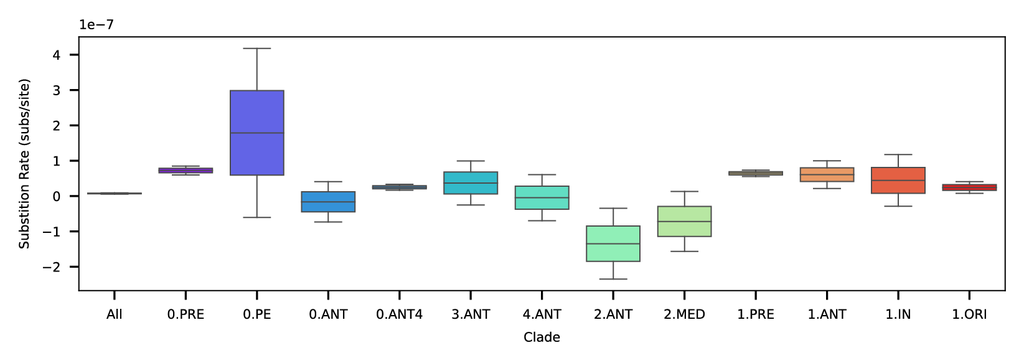

#### Clock Model

- Relaxed clock MCMC runs produce a high Coefficient of Variation indicating a relaxed model is favored over a strict model (Figure 7). However, these runs do not converge, suggesting there is too much rate variation to confidently estimate key parameters such as the mean Substitution Rate or tMRCA.

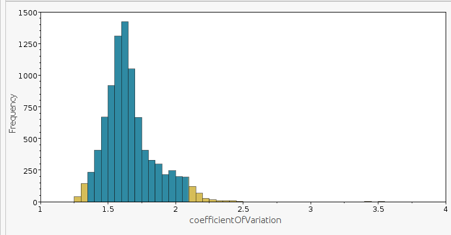

Figure 7: Coefficient of variation.

- A strict clock and relaxed clock have overlapping distributions with similar peaks for the Tree Height (blue: strict, green: relaxed) (Figure 8).

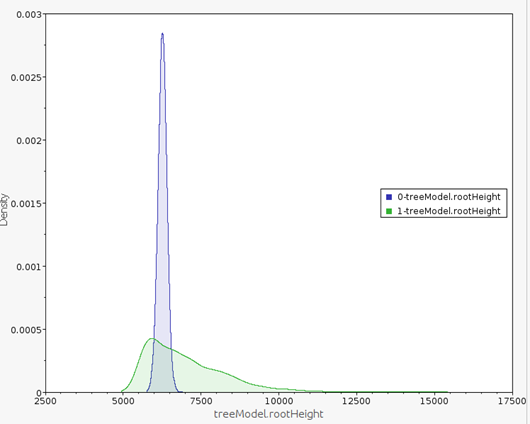

Figure 8: Tree height comparison.

- When estimating a Substitution Rate for all of *Y. pestis*, a [[Clock Model|strict clock]] and relaxed clock produce different estimates (green: strict, orange: relaxed) (Figure 9).

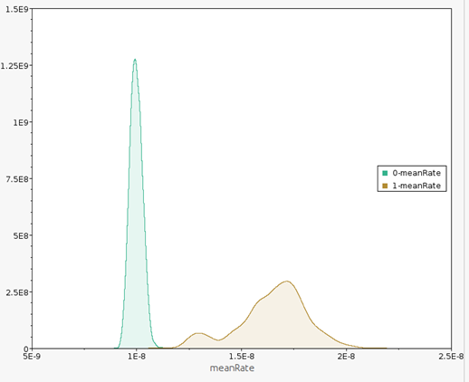

Figure 9: Substitution rate comparison.

- There doesn’t appear to be clustering of rates. Branches with high rates are next to those with low rates (Figure 10).

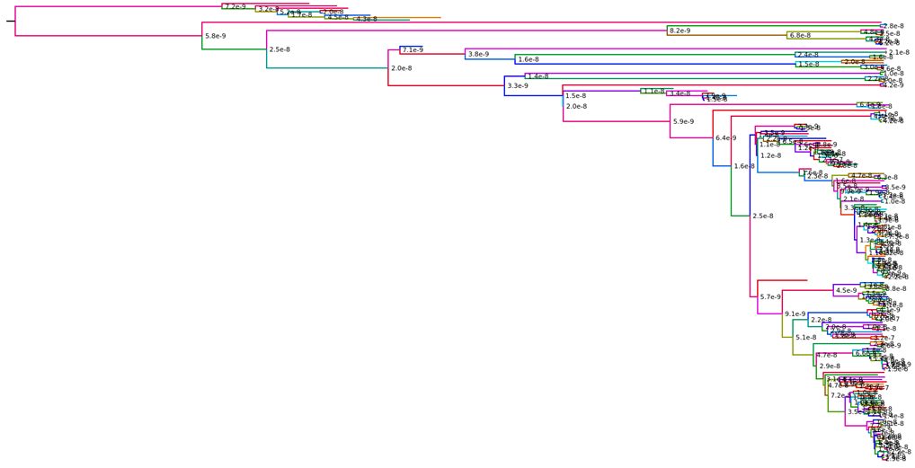

Figure 10: Time tree colored by rate.

## References

1. **The Stone Age Plague and Its Persistence in Eurasia**  
Aida Andrades Valtueña, Alissa Mittnik, Felix M. Key, Wolfgang Haak, Raili Allmäe, Andrej Belinskij, Mantas Daubaras, Michal Feldman, Rimantas Jankauskas, Ivor Janković, … Johannes Krause  
*Current Biology* (2017-12-04)  
DOI: 10.1016/j.cub.2017.10.025 · PMID: 29174893

2. **Emergence and spread of basal lineages of *Yersinia pestis* during the Neolithic Decline**  
Nicolás Rascovan, Karl-Göran Sjögren, Kristian Kristiansen, Rasmus Nielsen, Eske Willerslev, Christelle Desnues, Simon Rasmussen  
*Cell* (2019-01-10) https://www.cell.com/cell/abstract/S0092-8674(18)31464-8  
DOI: 10.1016/j.cell.2018.11.005 · PMID: 30528431

3. **Trade routes and plague transmission in pre-industrial Europe**  
Ricci P. H. Yue, Harry F. Lee, Connor Y. H. Wu  
*Scientific Reports* (2017-10-11) https://www.ncbi.nlm.nih.gov/pmc/articles/PMC5636801/  
DOI: 10.1038/s41598-017-13481-2 · PMID: 29021541 · PMCID: PMC5636801

4. **Yersinia pestis–etiologic agent of plague**  
R. D. Perry, J. D. Fetherston  
*Clinical Microbiology Reviews* (1997-01)  
PMID: 8993858 · PMCID: PMC172914

5. **Plague**  
World Health Organization  
(2017-10-31) https://www.who.int/news-room/fact-sheets/detail/plague

6. **The Black Death, 1346-1353: The Complete History**  
O. J. Benedictow  
*Boydell Press* (2004)  
ISBN: 0-85115-943-5

7. **Plague around the world in 2019**  
Eric Bertherat  
*Weekly Epidemiological Record* (2019-06-21) https://apps.who.int/iris/bitstream/handle/10665/325481/WER9425-en-fr.pdf

8. **Recent trends in plague ecology**  
K Gage, M Kosoy  
(2006) http://reviverestore.org/wp-content/uploads/2015/02/Gage-and-Kosoy_USGS-Blk-footed-ferret-symp_2006-copy.pdf

9. **Yersinia pestis, the cause of plague, is a recently emerged clone of Yersinia pseudotuberculosis**  
M. Achtman, K. Zurth, G. Morelli, G. Torrea, A. Guiyoule, E. Carniel  
*Proceedings of the National Academy of Sciences of the United States of America* (1999-11-23)  
DOI: 10.1073/pnas.96.24.14043 · PMID: 10570195 · PMCID: PMC24187

10. **Insights into the evolution of Yersinia pestis through whole-genome comparison with Yersinia pseudotuberculosis**  
P. S. G. Chain, E. Carniel, F. W. Larimer, J. Lamerdin, P. O. Stoutland, W. M. Regala, A. M. Georgescu, L. M. Vergez, M. L. Land, V. L. Motin, … E. Garcia  
*Proceedings of the National Academy of Sciences* (2004-09-21) http://www.pnas.org/cgi/doi/10.1073/pnas.0404012101  
DOI: 10.1073/pnas.0404012101

11. **NCBImeta**  
Katherine Eaton  
*NCBImeta* (2019) https://github.com/ktmeaton/NCBImeta

12. **GeoPy: A Python client for several popular geocoding web services.**  
Kostya Esmukov  
(2020-12) https://github.com/geopy/geopy

13. **Nominatim: A tool to search OpenStreetMap data.**  
Sarah Hoffman  
(2020-12) https://github.com/osm-search/Nominatim

14. **Planet dump retrieved from https://planet.osm.org**  
OpenStreetMap Contributors  
(2017) https://www.openstreetmap.org

15. **Snippy: Rapid haploid variant calling and core genome alignment.**  
Torsten Seemann  
(2020-03-08) https://github.com/tseemann/snippy

16. **ncbi/sra-tools**  
NCBI - National Center for Biotechnology Information/NLM/NIH  
(2021-05-18) https://github.com/ncbi/sra-tools

17. **Reproducible, portable, and efficient ancient genome reconstruction with nf-core/eager**  
James A. Fellows Yates, Thiseas C. Lamnidis, Maxime Borry, Aida Andrades Valtueña, Zandra Fagernäs, Stephen Clayton, Maxime U. Garcia, Judith Neukamm, Alexander Peltzer  
*PeerJ* (2021-03-16) https://peerj.com/articles/10947  
DOI: 10.7717/peerj.10947

18. **Historical variations in mutation rate in an epidemic pathogen, *Yersinia pestis***  
Y. Cui, C. Yu, Y. Yan, D. Li, Y. Li, T. Jombart, L. A. Weinert, Z. Wang, Z. Guo, L. Xu, … R. Yang  
*Proceedings of the National Academy of Sciences* (2013-01-08) http://www.pnas.org/cgi/doi/10.1073/pnas.1205750110  
DOI: 10.1073/pnas.1205750110

19. **ModelFinder: fast model selection for accurate phylogenetic estimates**  
Subha Kalyaanamoorthy, Bui Quang Minh, Thomas K. F. Wong, Arndt von Haeseler, Lars S. Jermiin  
*Nature Methods* (2017-06) http://www.nature.com/articles/nmeth.4285  
DOI: 10.1038/nmeth.4285

20. **IQ-TREE 2: New Models and Efficient Methods for Phylogenetic Inference in the Genomic Era**  
Bui Quang Minh, Heiko A. Schmidt, Olga Chernomor, Dominik Schrempf, Michael D. Woodhams, Arndt von Haeseler, Robert Lanfear  
*Molecular Biology and Evolution* (2020-05-01) https://academic.oup.com/mbe/article/37/5/1530/5721363  
DOI: 10.1093/molbev/msaa015

21. **UFBoot2: Improving the Ultrafast Bootstrap Approximation**  
Diep Thi Hoang, Olga Chernomor, Arndt von Haeseler, Bui Quang Minh, Le Sy Vinh  
*Molecular Biology and Evolution* (2018-02-01) https://academic.oup.com/mbe/article/35/2/518/4565479  
DOI: 10.1093/molbev/msx281

22. **Fast Dating Using Least-Squares Criteria and Algorithms**  
Thu-Hien To, Matthieu Jung, Samantha Lycett, Olivier Gascuel  
*Systematic Biology* (2016-01) https://academic.oup.com/sysbio/article-lookup/doi/10.1093/sysbio/syv068  
DOI: 10.1093/sysbio/syv068

23. **TreeTime: Maximum-likelihood phylodynamic analysis**  
Pavel Sagulenko, Vadim Puller, Richard A Neher  
*Virus Evolution* (2018-01-08) https://www.ncbi.nlm.nih.gov/pmc/articles/PMC5758920/  
DOI: 10.1093/ve/vex042 · PMID: 29340210 · PMCID: PMC5758920

24. **Historical and genomic data reveal the influencing factors on global transmission velocity of plague during the Third Pandemic**  
Lei Xu, Leif C. Stige, Herwig Leirs, Simon Neerinckx, Kenneth L. Gage, Ruifu Yang, Qiyong Liu, Barbara Bramanti, Katharine R. Dean, Hui Tang, … Zhibin Zhang  
*Proceedings of the National Academy of Sciences* (2019-06-11) https://www.pnas.org/content/116/24/11833  
DOI: 10.1073/pnas.1901366116 · PMID: 31138696

25. **Historical *Y. pestis* Genomes Reveal the European Black Death as the Source of Ancient and Modern Plague Pandemics**  
Maria A. Spyrou, Rezeda I. Tukhbatova, Michal Feldman, Joanna Drath, Sacha Kacki, Julia Beltrán de Heredia, Susanne Arnold, Airat G. Sitdikov, Dominique Castex, Joachim Wahl, … Johannes Krause  
*Cell Host & Microbe* (2016-06) http://linkinghub.elsevier.com/retrieve/pii/S1931312816302086  
DOI: 10.1016/j.chom.2016.05.012

26. *Yersinia pestis* genome sequencing identifies patterns of global phylogenetic diversity  
Giovanna Morelli, Yajun Song, Camila J. Mazzoni, Mark Eppinger, Philippe Roumagnac, David M. Wagner, Mirjam Feldkamp, Barica Kusecek, Amy J. Vogler, Yanjun Li, … Mark Achtman  
*Nature Genetics* (2010-12)  
DOI: 10.1038/ng.705 · PMID: 21037571 · PMCID: PMC2999892